# datos clínicos

Sergio Martí

14/11/2022

# Datos Clínicos pacientes Luis Miguel

Aquí vamos a importar los datos clínicos de los pacientes, facilitados por Luis Miguel. Se pretende usar estos datos clínicos como factores para comprobar si hay una relación de causalidad entre ellos y el desarrollo de un glioblastoma

Los datos se encuentran en un excel

```r
# Usamos la librería openxlsx para leer los datos clínicos de los pacientes del excel
library(openxlsx)

# Leemos el excel y lo guardamos como un dataframe
dfClinical <- openxlsx::read.xlsx("C:/Sergio/Curso 2022-23/Proyecto FISABIO/Luis Miguel/DATOS CLÍNICOS asociados a RNA-seq.xlsx", "Hoja1")

# Mostramos el dataframe en Rstudio
# View(dfClinical)
```

```r
# Cargamos las librerias gráficas porque las vamos a utilizar en varios chunks
library(ggplot2)
library(gridExtra)

# Para el dendograma
library(ggdendro)
library(plotly)
```

Los fáctores de mayor interés para Camino y Luis Miguel son: edad del paciente cuando se diagnostico la enfermedad, el género, la localización del tumor, la supervivencia y el grado del glioblastoma. Además hay otras columnas que describen otras características de los pacientes, pero por ahora no se tiene nada pensando.

Es necesario hacer un trabajo de pre-procesado de datos, para transformar las variables a factores y asegurarse que cumplen los requisitos necesarios para seguir con el análisis.

## Edad del paciente cuando se diagnostico la enfermedad

La edad del paciente cuando se dianostico la enfermedad. Camino agrupo a los pacientes en cuatro grupos de edad, a “saltos” de 10 años. Para distribuir de forma más uniforme el número de pacientes en función de su edad, se van a separar en cuartiles. Se añade al dataframe como una variable de tipo factor.

```r
# Guardamos como un vector la variable
lAge <- dfClinical$Age.at.diagnosis

# Hacemos un summary
sprintf("Summary Age at diagnosis")
```

```
## [1] "Summary Age at diagnosis"
```

```r
summary(lAge)
```

```
##    Min. 1st Qu.  Median    Mean 3rd Qu.    Max.
##   32.00   45.75   52.50   54.21   65.00   76.00
```

```r
# Podemos usar la función "quantile" para sacar los cuartiles
lQuartiles <- quantile(lAge, probs=c(0.25, 0.5, 0.75))

# Definimos una función, a la cual, dado un valor, devolverá un texto dependiendo de si se encuentra en el primer, segundo, tercer o cuarto cuartil
AssingQuartil <- function(iValue, lQuartiles, lNames) {
  if (iValue < lQuartiles[1]) {
    return(lNames[1])
  } else if (iValue >= lQuartiles[1] && iValue < lQuartiles[2]) {
    return(lNames[2])
  } else if (iValue >= lQuartiles[2] && iValue < lQuartiles[3]) {
    return(lNames[3])
  } else if (iValue >= lQuartiles[3]) {
    return(lNames[4])
  } else {
    return(NULL)
  }
}

# Aplicamos la función sobre la lista de edades. Deshacemos la lista para convertirlo en vector, convertimos a factor, y añadimos como columna en el dataframe
dfClinical$fAge <- as.factor(unlist(lapply(lAge, function(x) AssingQuartil(x, lQuartiles, c("quartil 1", "quartil 2", "quartil 3", "quartil 4")))))

# Comprobamos el número de pacientes en cada cuartil
sprintf("Table number of patients / quartile")
```

```
## [1] "Table number of patients / quartile"
```

```r
table(dfClinical$fAge)
```

```
##
## quartil 1 quartil 2 quartil 3 quartil 4
##         7         7         6         8
```

## Género del paciente

El género del paciente. Hombre (M) y mujer (F). Añadimos al dataframe como un factor más.

```r
# Añadimos como un factor el género
dfClinical$fGender <- as.factor(dfClinical$Gender)

# Mostramos algunos datos:
sprintf("Table number of patients by gender")
```

```
## [1] "Table number of patients by gender"
```

```r
table(dfClinical$fGender)
```

```
##
##  F  M
## 11 17
```

## Localización del tumor

Se tendrá en cuenta estas observaciones para extrer dos factores de esta variable: el factor de la localización del tumor según el hemisferio y el factor de la localización del tumor según el lóbulo.

```r
# Definimos una función que clasifica en función de una variable tipo "string" (s), si contiene "Left" o "right". Si no contiene una de estas dos palabras, devuelve nulo
AssignCerebralHemisphere <- function(sValue) {
  if (grepl("[Ll]eft", sValue)) {
    return("left")
  } else if (grepl("[Rr]ight", sValue)) {
    return("right")
  } else {
    return(NULL)
  }
}

# Creamos un factor con esta función
dfClinical$fTumorHemisphere <- as.factor(unlist(lapply(dfClinical$Tumor.localization, function(x) AssignCerebralHemisphere(x))))

# Mostramos cuantos pacientes hay por grupo
table(dfClinical$fTumorHemisphere)
```

```
##
##  left right
##    13    15
```

```r
# Hacemos lo mismo para clasificar en función del lóbulo cerebral

AssignCerebralLobule <- function(sValue) {
  if (grepl("[Oo]ccipital", sValue)) {
    return("occipital")
  } else if (grepl("[Pp]ariet", sValue)) {
    return("parietal")
  } else if (grepl("[Ff]ront", sValue)) {
    return("frontal")
  } else if (grepl("[Tt]emporal", sValue)) {
    return("temporal")
  } else {
    return(NULL)
  }
}

dfClinical$fTumorLobule <- as.factor(unlist(lapply(dfClinical$Tumor.localization, function(x) AssignCerebralLobule(x))))

table(dfClinical$fTumorLobule)
```

```
##
##   frontal occipital  parietal  temporal
##         8         4         7         9
```

```r
# Podemos contabilizar los individuos con los dos factores conjuntamente
table(dfClinical$fTumorHemisphere, dfClinical$fTumorLobule)
```

```
##
##         frontal occipital parietal temporal
##   left        4         2        3        4
##   right       4         2        4        5
```

## Supervivencia

También se tiene registrado los datos de la supervivencia. Se supone que son semanas desde el diagnóstico de la enfermedad. Hay que confirmarlo con Luis Miguel.

pero, se puede comprobar si son semanas, convirtiendo la supervivencia a años y sumandola a la edad de diagnóstico. Si las edades resultantes entran dentro de lo razonable, se afianza esta suposición.

```r
round(unlist(lapply(dfClinical$Survival, function(weeks) {
  if (!is.na(as.numeric(weeks))) {
    return(strtoi(weeks, base = 0L) / 52.1429) # Un año tiene 52.1429 semanas...
  } else {
    return(0)
  }
})) + dfClinical$Age.at.diagnosis, 2)
```

```
##  [1]  65.26  75.68 109.90  76.76  74.79  52.42  60.34  72.75  68.82  38.62
## [11]  61.09  74.43  75.76  33.00  70.54  43.00  47.92  65.51  66.02  83.58
## [21]  55.04  47.40  33.00  45.00  48.52  62.89  68.44  81.14
```

Ahora hacemos un breve análisis descriptivo de la variable de la supervivencia.

```r
# Hacemos un summary de la variable, tomandola como si fuera numérica
summary(as.numeric(dfClinical$Survival))
```

```
##    Min. 1st Qu.  Median    Mean 3rd Qu.    Max.    NA's
##    22.0   127.8   317.0   520.6   597.8  3384.0       4
```

```r
# Hay valores NA, por lo tanto se van a omitir para calcular la desviación típica y la varianza. El resto de valores, se van transformar a numeros enteros
lNumSurvival <- strtoi(dfClinical$Survival[!is.na(as.numeric(dfClinical$Survival))], base = 0L)

sprintf("Varianza: %.3f", var(lNumSurvival))
```

```
## [1] "Varianza: 506412.428"
```

```r
sprintf("Desviación típica: %.3f", sd(lNumSurvival))
```

```
## [1] "Desviación típica: 711.627"
```

Hay dos problemas con esta variable. El primero es que hay valores que son “NA’s” (acronimo de Not Available). El segundo, es que hay una varianza muy grande, eso significa que esta variable toma un rango de valores muy amplio. Como se quiere convertir esta variable numérica a un factor, sería recomendable reducir la varianza. Para ello, Se va a aplicar una transformación logaritmica (de base 10). Para variables de tipo temporal, es un procedimiento habitual.

```r
# Transformación
lLogSurvival <- log10(lNumSurvival)

# Descripción de la variable transformada
summary(lLogSurvival)
```

```
##    Min. 1st Qu.  Median    Mean 3rd Qu.    Max.
##   1.342   2.106   2.499   2.410   2.776   3.529
```

```r
sprintf("Varianza: %.3f", var(lLogSurvival))
```

```
## [1] "Varianza: 0.326"
```

```r
sprintf("Desviación típica: %.3f", sd(lLogSurvival))
```

```
## [1] "Desviación típica: 0.571"
```

Sería una buena idea, partir la población en función de la supervivencia en tres grupos: poca supervivencia, supervivencia media y supervivencia alta. Para esto, se pueden calcular los terciles (los cuantiles que dividen la población en tres partes iguales).

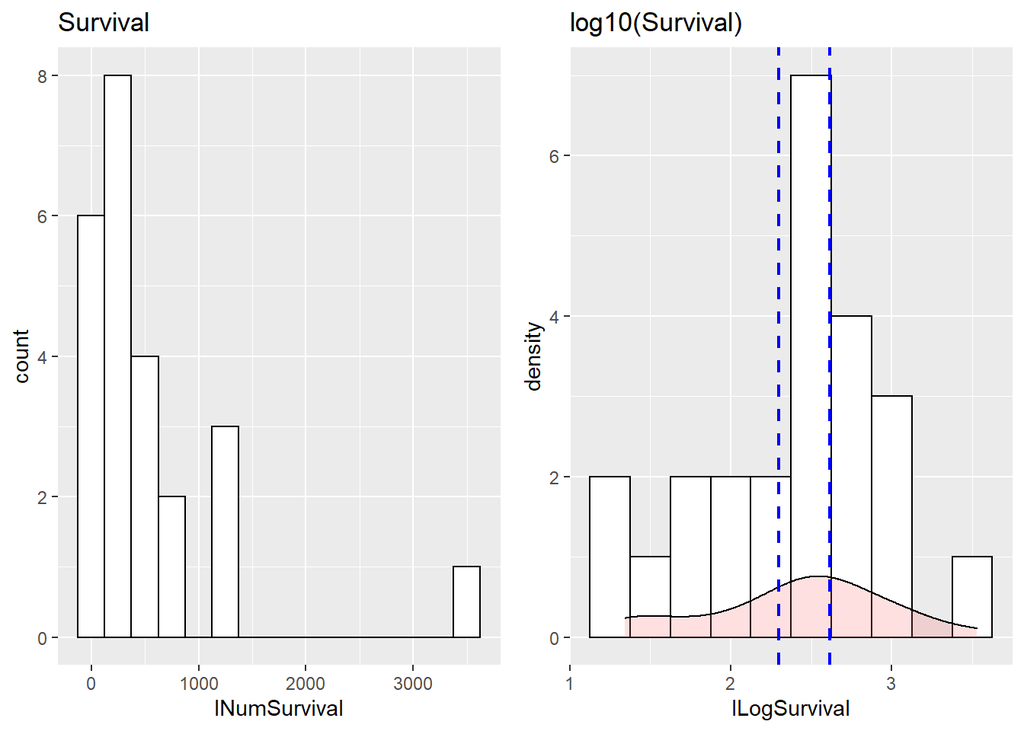

```r
# Tertile = Tercil <-> Terciles: cuantiles que dividen la distribución en tres grupos.
lTertile <- quantile(lLogSurvival, probs = c(0.33, 0.66))

# Representación gráfica
library(ggplot2)
library(gridExtra)

# Datos de supervivencia sin transformar
g1 <- ggplot(as.data.frame(lNumSurvival), aes(x=lNumSurvival)) +
  geom_histogram(binwidth=250, color="black", fill="white") +
  ggtitle("Survival")

# Datos de supervivencia transformados (log10)
g2 <- ggplot(as.data.frame(lLogSurvival), aes(x=lLogSurvival)) +
  geom_histogram(binwidth=0.25, color="black", fill="white") +
  geom_density(alpha=.2, fill="#FF6666") +
  geom_vline(aes(xintercept=lTertile[1]), color="blue", linetype="dashed", size=0.75) +
  geom_vline(aes(xintercept=lTertile[2]), color="blue", linetype="dashed", size=0.75) +
  ggtitle("log10(Survival)")

grid.arrange(g1, g2, nrow = 1)
```

```r
rm(g1, g2)
```

Ahora se puede clasificar la supervivencia en tres grupos:

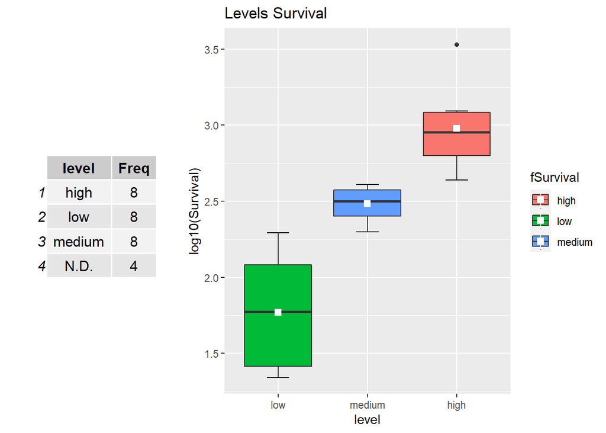

```r
# Definimos una función que asigna el grupo en función del valor y los terciles, pero, personalizada para la variable de supervivencia
AssignTertil <- function(x, lTertil, lNames) {
  if (!is.na(as.numeric(x))) {

    iValue <- strtoi(x, base = 0L)

    fLogValue <- log10(iValue)

    if (fLogValue < lTertil[1]) {
      return(lNames[1])
    } else if (fLogValue >= lTertil[1] && fLogValue < lTertil[2]) {
      return(lNames[2])
    } else if (fLogValue >= lTertil[2]) {
      return(lNames[3])
    } else {
      return(NULL)
    }

  } else {
    return("N.D.")
  }
}

# Añadimos la variable al dataframe
dfClinical$fSurvival <- as.factor(unlist(lapply(dfClinical$Survival, function(x) AssignTertil(x, lTertile, c("low", "medium", "high")))))

t1 <- as.data.frame(table(dfClinical$fSurvival))
colnames(t1) <- c("level", "Freq")
t1 <- tableGrob(t1)

# Gráficamos la supervivencia en semanas en base al factor recien creado
g1 <- ggplot(dfClinical[dfClinical$fSurvival != "N.D.",],
       aes(x = reorder(fSurvival, as.numeric(Survival)), y = log10(as.numeric(Survival)), fill = fSurvival)) +
  stat_boxplot(geom = "errorbar", width = 0.25) +
  geom_boxplot() +
  stat_summary(fun="mean", color="white", shape=15) +
  xlab("level") +
  ylab("log10(Survival)") +
  ggtitle("Levels Survival")

grid.arrange(t1, g1, ncol = 2, widths = c(0.75, 1.75), clip = FALSE)
```

```r
rm(g1, t1)
```

El problema de generar los niveles del factor con este método, es que al dividir la población según el criterio de los cuantiles, se están agrupando los pacientes por cantidad y no por la cualidad de la supervivencia. Es un buen método para la edad (ya que es una variable más o menos uniforme), pero en este caso es necesario aplicar otro algorítmo de agrupamiento.

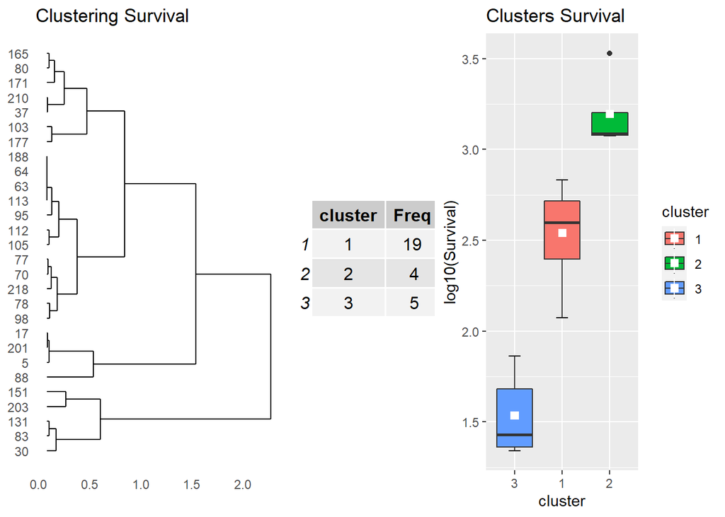

```r
# Para lo que voy a hacer, prefiero mantener el orden original
# Podríamos hablar de fabricación de los datos, pero solamente es para mantener el orden original del dataframe/excel y poder asignar grupos a los individuos correctos
lNumReplacedSurvival <- as.numeric(replace(dfClinical$Survival, dfClinical$Survival == "N.D.", floor(mean(lNumSurvival))))

# Voy a hacer un clustering jerárquico
# Después de probar los métodos para el clustering jerárquico, he elegido el método complete
# Calculo la matriz de distancias, aplicando la transformación del logaritmo, para que las distancias sean menores, y me haga grupos con más individuo por cluster
lLog10ReplacedSurvival <- log10(lNumReplacedSurvival)
names(lLog10ReplacedSurvival) <- dfClinical$Samples
hc <- hclust(dist(lLog10ReplacedSurvival), method="complete")

# Ahora genero el número de clusters deseados, en este caso 3
fSurvival <- cutree(hc, k = 3)

# Muestro la agrupación y ploteo los datos
dfSurvival <- data.frame(lNumReplacedSurvival, as.factor(fSurvival))
colnames(dfSurvival) <- c("weeks", "cluster")

# Tabla
t1 <- as.data.frame(table(dfSurvival$cluster))
colnames(t1) <- c("cluster", "Freq")
t1 <- tableGrob(t1)

# boxplot
g1 <- ggplot(dfSurvival, aes(x = reorder(cluster, weeks), y = log10(weeks), fill = cluster)) +
  stat_boxplot(geom = "errorbar", width = 0.25) +
  xlab("cluster") +
  ylab("log10(Survival)") +
  geom_boxplot() +
  stat_summary(fun="mean", color="white", shape=15) +
  ggtitle("Clusters Survival")

# dendograma
hcplot <- ggdendro::ggdendrogram(hc, rotate = TRUE) +
  ggtitle("Clustering Survival")

grid.arrange(hcplot, t1, g1, nrow = 1, widths = c(1, 0.50, 1), clip = FALSE)
```

```r
# El resultado es bueno, así que guardamos el nuevo factor de supervivencia
dfClinical$fSurvival <- dfSurvival$cluster

# Asignamos los pacientes con N.D.
dfClinical[dfClinical$Survival == "N.D.",]$fSurvival = NULL

rm(lLog10ReplacedSurvival, hc, hcplot, t1, g1)
```

## Grado del glioblastoma

Los datos sobre grado del glioblastoma si que no son uniformes. Solamente hay datos de glioblastomas con grado II y grado IV. Además, hay una sobrerepresentación del grado IV (o una subrepresentación de grado II, según se quiera ver), existiendo solamente 4 pacientes con glioblastoma grado II.

```r
fGrade <- as.factor(dfClinical$Grade)

table(fGrade)
```

```
## fGrade
## II IV
##  4 24
```

## ¿La edad está correlacionada con la supervivencia?

Dado que tenemos dos variables numéricas que hemos estudiado, podemos hacer una regression para comprobar si existe correlación.

```r
# Regressión líneal (aplicando transformación log10 a la variable independiente)
x <- dfClinical[dfClinical$Survival !="N.D.",]$Age.at.diagnosis
y <- log10(as.numeric(dfClinical[dfClinical$Survival !="N.D.",]$Survival))
regression <- lm(y ~ x)

summary(regression)
```

```
##
## Call:
## lm(formula = y ~ x)
##
## Residuals:
##      Min       1Q   Median       3Q      Max
## -1.09845 -0.26526  0.08267  0.40651  1.04421
##
## Coefficients:
##              Estimate Std. Error t value Pr(>|t|)
## (Intercept)  2.770299   0.608287   4.554 0.000156 ***
## x           -0.006335   0.010499  -0.603 0.552415
## ---
## Signif. codes:  0 '***' 0.001 '**' 0.01 '*' 0.05 '.' 0.1 ' ' 1
##
## Residual standard error: 0.579 on 22 degrees of freedom
## Multiple R-squared:  0.01628,    Adjusted R-squared:  -0.02843
## F-statistic: 0.3641 on 1 and 22 DF,  p-value: 0.5524
```

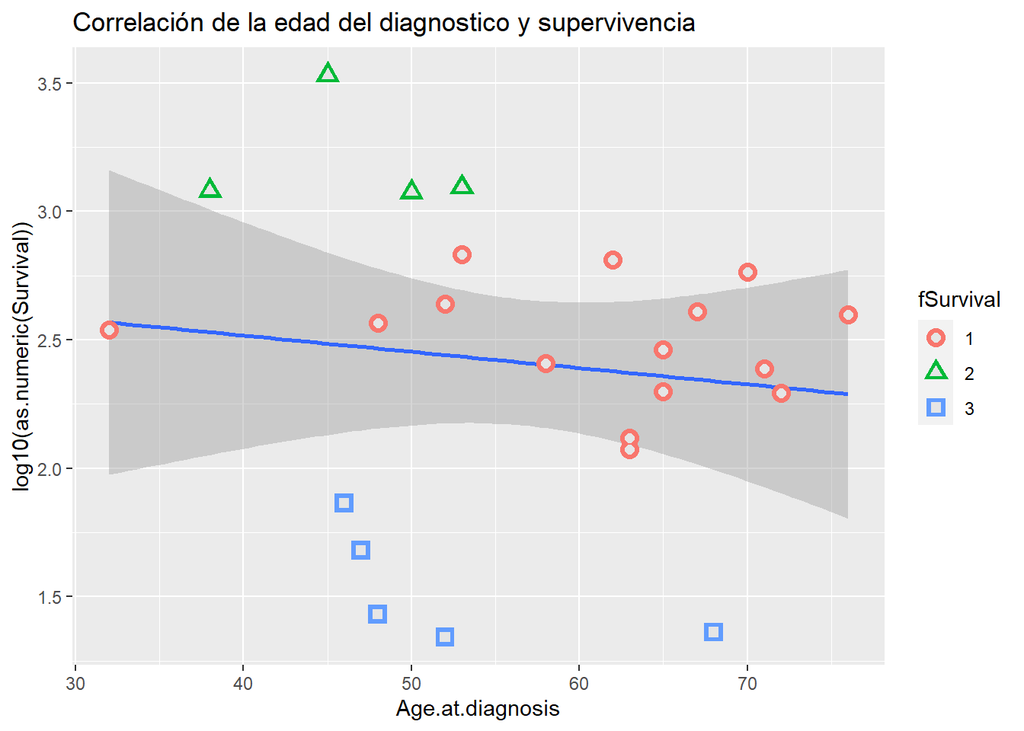

```r
ggplot(dfClinical[dfClinical$Survival != "N.D.",], aes(x = Age.at.diagnosis, y = log10(as.numeric(Survival)))) +
  ggtitle("Correlación de la edad del diagnostico y supervivencia") +
  geom_smooth(method = "lm", formula = y ~ x) +
  geom_point(aes(col = fSurvival, shape = fSurvival), size = 4) +
  geom_point(aes(shape = fSurvival), colour = "grey90", size = 2)
```

En principio, no se ve una correlación ya que el R^2 que resulta de la regresión, es muy bajo. Cualquier estimación tendría unos margenes de error muy grandes.

## ¿El género y la localización del tumor afectan a la supervivencia?

¿Hay diferencias signficativas de la supervivencia según el género del paciente?

```r
# ------------------------------------------------------- #
# --- Diferencias en la supervivencia según el género --- #
# ------------------------------------------------------- #

# CONTRASTE IGUALDAD MEDIAS (para 2 poblaciones independientes)

males <- log10(as.numeric(dfClinical[dfClinical$Survival != "N.D." & dfClinical$fGender == "M",]$Survival))
females <- log10(as.numeric(dfClinical[dfClinical$Survival != "N.D." & dfClinical$fGender == "F",]$Survival))

# --- Supuesto de la Normalidad

# Contraste estadístico de la normalidad
# p-value > 0.05, no se rechaza la hipotesis nula = se cumple la normalidad
shapiro.test(males)
```

```
##
##  Shapiro-Wilk normality test
##
## data:  males
## W = 0.94046, p-value = 0.4242
```

```r
shapiro.test(females)
```

```
##
##  Shapiro-Wilk normality test
##
## data:  females
## W = 0.96022, p-value = 0.7884
```

```r
# --- Supuesto de la Homocedasticidad u homogeneidad de varianzas
# p-value > 0.05, no se rechaza la hipotesis nula = no hay diferencias significativas en la varianza = se cumple la homogeneidad de varianzas
var.test(males, females)
```

```
##
##  F test to compare two variances
##
## data:  males and females
## F = 1.7566, num df = 13, denom df = 9, p-value = 0.4008
## alternative hypothesis: true ratio of variances is not equal to 1
## 95 percent confidence interval:
##  0.4585829 5.8180678
## sample estimates:
## ratio of variances
##           1.756646
```

```r
# Contraste igualdad de medias
# p-value > 0.05, no se rechaza la hipotesis nula = las medias no son significativamente diferentes
t.test(
  males,
  females,
  alternative = "two.sided",
  paired = FALSE,
  var.equal = TRUE
)
```

```
##
##  Two Sample t-test
##
## data:  males and females
## t = 0.75007, df = 22, p-value = 0.4612
## alternative hypothesis: true difference in means is not equal to 0
## 95 percent confidence interval:
##  -0.3159558  0.6740001
## sample estimates:
## mean of x mean of y
##  2.484847  2.305825
```

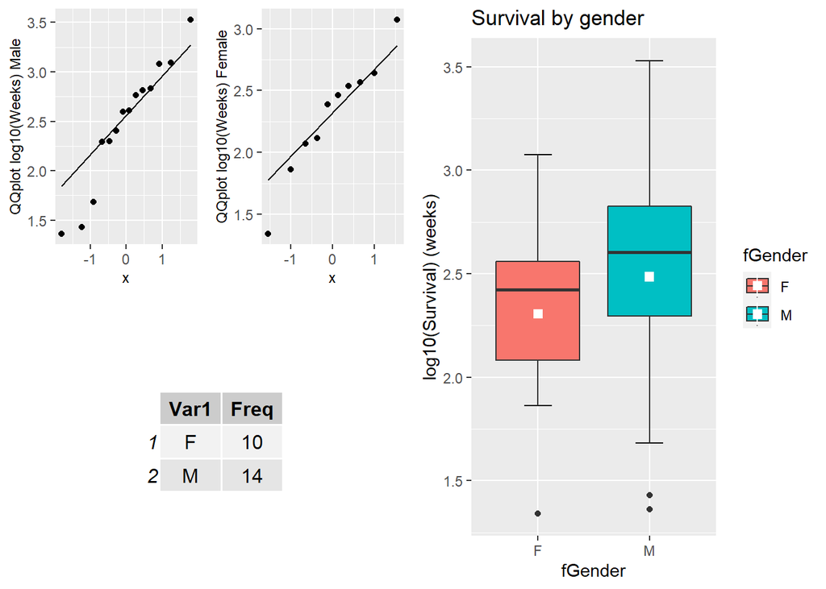

```r
# --- GRAFICAS --- #
# Diagrama de bigotes
g1 <- ggplot(dfClinical[dfClinical$Survival != "N.D.",], aes(x = fGender, y = log10(as.numeric(Survival)), fill = fGender)) +
  stat_boxplot(geom = "errorbar", width = 0.25) +
  geom_boxplot() +
  stat_summary(fun="mean", color="white", shape=15) +
  ylab("log10(Survival) (weeks)") +
  ggtitle("Survival by gender")

# Número de individuos por nivel
t1 <- tableGrob(as.data.frame(table(dfClinical[dfClinical$Survival != "N.D.",]$fGender)))

# Comprobación gráfica de la normalidad
gQQ1 <- ggplot(dfClinical[dfClinical$Survival != "N.D." & dfClinical$fGender == "M",], aes(sample = log10(as.numeric(Survival)))) +
  stat_qq() +
  stat_qq_line() +
  theme(axis.title =element_text(size = 9)) +
  ylab("QQplot log10(Weeks) Male")

gQQ2 <- ggplot(dfClinical[dfClinical$Survival != "N.D." & dfClinical$fGender == "F",], aes(sample = log10(as.numeric(Survival)))) +
  stat_qq() +
  stat_qq_line() +
  theme(axis.title = element_text(size = 9)) +
  ylab("QQplot log10(Weeks) Female")

# Gráfico final
grid.arrange(gQQ1, gQQ2, t1, g1,
             widths = c(1, 1, 2),
             layout_matrix = rbind(c(1, 2, 4), c(3, 3, 4)))
```

```r
rm(male, female, g1, t1, gQQ1, gQQ2)
```

No, no hay diferencias signficativas en la supervivencia según el género paciente.

¿Hay diferencias significativas en la supervivencia según el hemisferio cerebral donde se desarrollo el tumor?

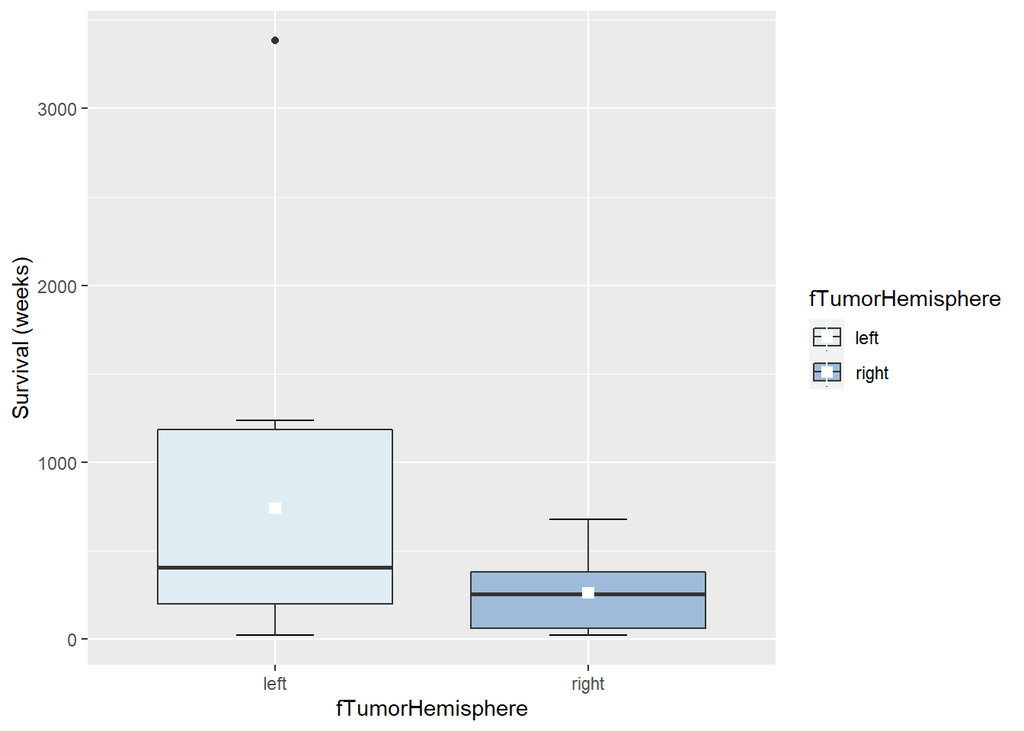

```r
ggplot(dfClinical[dfClinical$Survival != "N.D.",], aes(x = fTumorHemisphere, y = as.numeric(Survival), fill = fTumorHemisphere)) +
  stat_boxplot(geom = "errorbar", width = 0.25) +
  geom_boxplot() +
  stat_summary(fun="mean", color="white", shape=15) +
  scale_fill_brewer(palette="BuPu") +
  ylab("Survival (weeks)")
```

No, no hay diferencias significativas en la supervivencia si comparamos los pacientes con tumor cerebral en el hemisferio izquierdo o derecho.

¿Hay diferencias significativas en la supervivencia según el lóbulo cerebral donde se desarrollo el tumor?

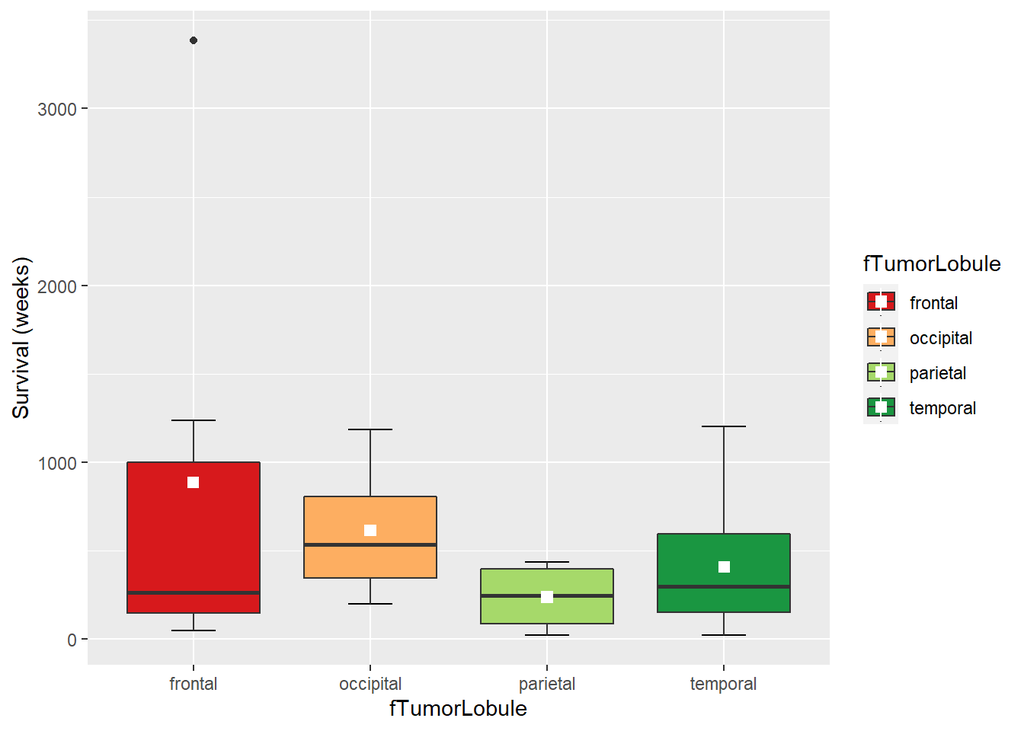

```r
ggplot(dfClinical[dfClinical$Survival != "N.D.",], aes(x = fTumorLobule, y = as.numeric(Survival), fill = fTumorLobule)) +
  stat_boxplot(geom = "errorbar", width = 0.25) +
  geom_boxplot() +
  stat_summary(fun="mean", color="white", shape=15) +
  scale_fill_brewer(palette="RdYlGn") +
  ylab("Survival (weeks)")
```

En un principio, no se detectan diferencias significativas en la supervivencia dependiendo del lóbulo donde aparece el tumor.

¿Y si tenemos varios factores en cuenta, hay diferencias significativas?

Agrupamos en función del hemisferio y el lóbulo.

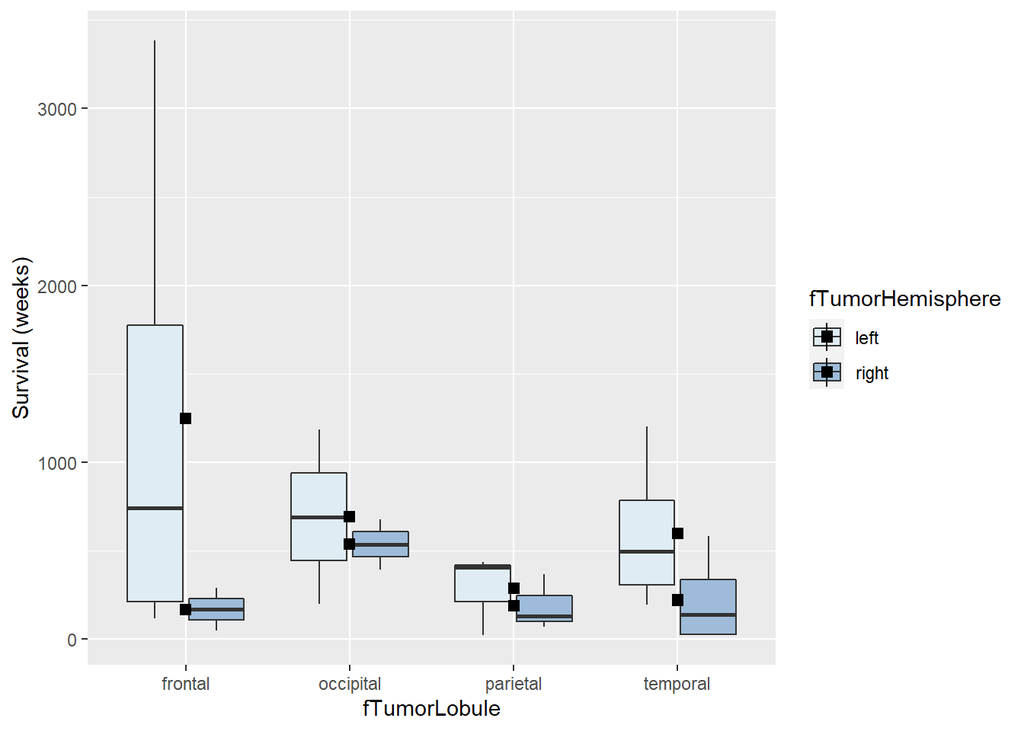

```r
ggplot(dfClinical[dfClinical$Survival != "N.D.",], aes(x = fTumorLobule, y = as.numeric(Survival), fill = fTumorHemisphere)) +
  geom_boxplot() +
  stat_summary(fun="mean", color="black", shape=15) +
  scale_fill_brewer(palette="BuPu") +
  ylab("Survival (weeks)")
```

Agrupamos en función del género y el lóbulo.

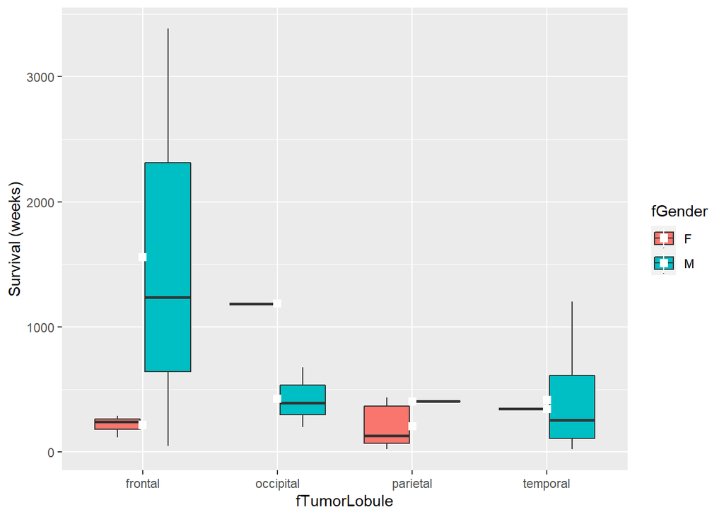

```r
ggplot(dfClinical[dfClinical$Survival != "N.D.",], aes(x = fTumorLobule, y = as.numeric(Survival), fill = fGender)) +
  geom_boxplot() +
  stat_summary(fun="mean", color="white", shape=15) +
  ylab("Survival (weeks)")
```

Y, por último, agrupamos en función del género y el hemisferio.

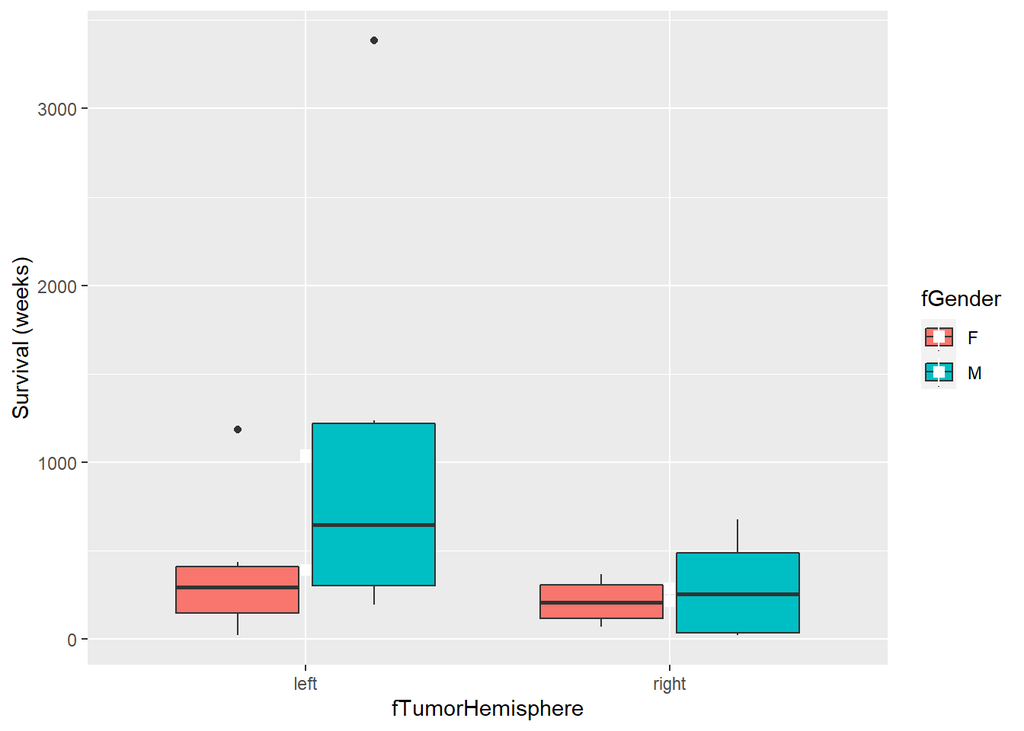

```r
ggplot(dfClinical[dfClinical$Survival != "N.D.",], aes(x = fTumorHemisphere, y = as.numeric(Survival), fill = fGender)) +
  geom_boxplot() +
  stat_summary(fun="mean", color="white", shape=15) +
  ylab("Survival (weeks)")
```

# Guardar los nuevos factores

Podemos guardar el trabajo, guardado el dataframe como un libro de excel:

```r
openxlsx::write.xlsx(dfClinical, "C:/Sergio/Curso 2022-23/Proyecto FISABIO/Luis Miguel/dfClinical.xlsx")
```